# New York Police Department Shootings Analysis

8/5/2023

#### This report analyzes shooting incident data from the New York Police Department to understand how shootings in New York have changed over time and how do they relate to location and demographic information.

I used the following libraries to complete this report: tidyverse, dplyr, zoo, and lubridate.

## Importing Data

This assignment is an exploration of incidents recorded by the NYPD since 2006. Each incident report has information about the perpetrator, the victim, the location, the time, and a few more details about the crime.

I will start by importing and reading the NYPD Shooting Incidents data which is sourced from the City of New York’s website.

```r
url_in <- "https://data.cityofnewyork.us/api/views/833y-fsy8/rows.csv"
shootings <- read_csv(url_in, show_col_types = FALSE)
```

## Data Exploration

Here I can take a look at the type of variables included in the data set.

```r
summary(shootings)
```

```
##   INCIDENT_KEY        OCCUR_DATE         OCCUR_TIME           BORO
##  Min.   :  9953245   Length:27312       Length:27312      Length:27312
##  1st Qu.: 63860880   Class :character   Class1:hms        Class :character
##  Median : 90372218   Mode  :character   Class2:difftime   Mode  :character
##  Mean   :120860536                      Mode  :numeric
##  3rd Qu.:188810230
##  Max.   :261190187
##
##  LOC_OF_OCCUR_DESC     PRECINCT      JURISDICTION_CODE LOC_CLASSFCTN_DESC
##  Length:27312       Min.   :  1.00   Min.   :0.0000    Length:27312
##  Class :character   1st Qu.: 44.00   1st Qu.:0.0000    Class :character
##  Mode  :character   Median : 68.00   Median :0.0000    Mode  :character
##                     Mean   : 65.64   Mean   :0.3269
##                     3rd Qu.: 81.00   3rd Qu.:0.0000
##                     Max.   :123.00   Max.   :2.0000
##                                      NA's   :2
##  LOCATION_DESC      STATISTICAL_MURDER_FLAG PERP_AGE_GROUP
##  Length:27312       Mode :logical           Length:27312
##  Class :character   FALSE:22046             Class :character
##  Mode  :character   TRUE :5266              Mode  :character
##
##
##
##
##    PERP_SEX          PERP_RACE         VIC_AGE_GROUP        VIC_SEX
##  Length:27312       Length:27312       Length:27312       Length:27312
##  Class :character   Class :character   Class :character   Class :character
##  Mode  :character   Mode  :character   Mode  :character   Mode  :character
##
##
##
##
##    VIC_RACE           X_COORD_CD        Y_COORD_CD        Latitude
##  Length:27312       Min.   : 914928   Min.   :125757   Min.   :40.51
##  Class :character   1st Qu.:1000029   1st Qu.:182834   1st Qu.:40.67
##  Mode  :character   Median :1007731   Median :194487   Median :40.70
##                     Mean   :1009449   Mean   :208127   Mean   :40.74
##                     3rd Qu.:1016838   3rd Qu.:239518   3rd Qu.:40.82
##                     Max.   :1066815   Max.   :271128   Max.   :40.91
##                                                        NA's   :10
##    Longitude        Lon_Lat
##  Min.   :-74.25   Length:27312
##  1st Qu.:-73.94   Class :character
##  Median :-73.92   Mode  :character
##  Mean   :-73.91
##  3rd Qu.:-73.88
##  Max.   :-73.70
##  NA's   :10
```

I want to find the variables that do not have a lot of missing values, so we know which columns we can work with.

```r
sapply(shootings, function(x) sum(is.na(x)))
```

```
##            INCIDENT_KEY              OCCUR_DATE              OCCUR_TIME
##                       0                       0                       0
##                    BORO       LOC_OF_OCCUR_DESC                PRECINCT
##                       0                   25596                       0
##       JURISDICTION_CODE      LOC_CLASSFCTN_DESC           LOCATION_DESC
##                       2                   25596                   14977
## STATISTICAL_MURDER_FLAG          PERP_AGE_GROUP                PERP_SEX
##                       0                    9344                    9310
##               PERP_RACE           VIC_AGE_GROUP                 VIC_SEX
##                    9310                       0                       0
##                VIC_RACE              X_COORD_CD              Y_COORD_CD
##                       0                       0                       0
##                Latitude               Longitude                 Lon_Lat
##                      10                      10                      10
```

## Data Transformation

Now let’s tidy up the data set and select only the most relevant columns to work with. We should also change the date variable into the correct data type.

```r
shootings <- shootings%>%
  select(c(OCCUR_DATE, OCCUR_TIME, BORO, VIC_AGE_GROUP, VIC_SEX, PERP_AGE_GROUP,PERP_SEX))%>%
  mutate(OCCUR_DATE = mdy(OCCUR_DATE))
```

## Data Visualizations & Model

### Shootings Over Time

Next, we will take a look at how the rate of shootings in NYC changed over time. I will use a 30-day moving average to show overall patterns throughout the years and be less susceptible to outliers.

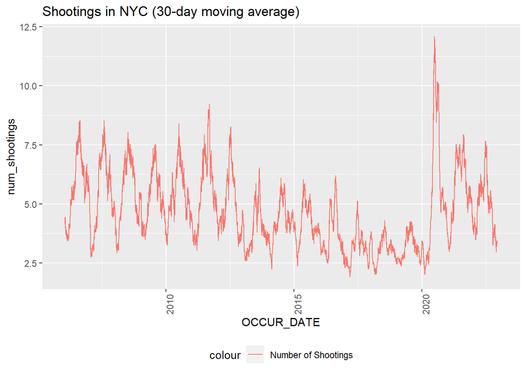

```r
agg_tbl <- shootings %>% group_by(OCCUR_DATE) %>%
  summarise(total_count=n(),.groups = 'drop')%>%
  mutate(num_shootings=rollmean(total_count, k = 30, fill = NA))

agg_tbl%>%
  ggplot(aes(x=OCCUR_DATE,y=num_shootings)) +
  geom_line(aes(color="Number of Shootings")) +
  theme (legend.position="bottom",
  axis.text.x = element_text(angle = 90)) +
  labs (title = "Shootings in NYC (30-day moving average)")
```

This graph demonstrates an oscillating pattern of shootings throughout each year, with spikes happening in the summer and dips during the winter. The large peak during the middle of 2020 raises questions about what specifically caused such a large spike in shootings during that time?